# R Markdown

Sean Kross

January 11, 2016

Markdown is a simple markdown language for producing HTML web pages. Below I’ll show markdown code, and then how that code looks when rendered to HTML:

### Headings

[output not shown]

# I’m huge!

## I’m still large

### Prose

```
It was the best of times, it was the worst of times, it was the age of wisdom,
it was the age of foolishness, it was the epoch of belief, it was the epoch of
incredulity, it was the season of Light, it was the season of Darkness, it was
the spring of hope, it was the winter of despair, we had everything before us,
we had nothing before us, we were all going direct to Heaven, we were all going
direct the other way – in short, the period was so far like the present period,
that some of its noisiest authorities insisted on its being received, for good
or for evil, in the superlative degree of comparison only.
```

It was the best of times, it was the worst of times, it was the age of wisdom, it was the age of foolishness, it was the epoch of belief, it was the epoch of incredulity, it was the season of Light, it was the season of Darkness, it was the spring of hope, it was the winter of despair, we had everything before us, we had nothing before us, we were all going direct to Heaven, we were all going direct the other way – in short, the period was so far like the present period, that some of its noisiest authorities insisted on its being received, for good or for evil, in the superlative degree of comparison only.

### Bold and italic

```
*italic*

**bold**

***bold and italic***
```

*italic*

**bold**

*bold and italic*

### Lists

```
- an item
- another item
- a thrid item
```

- an item
- another item
- a thrid item

```
1. an item
2. another item
3. a thrid item
```

1. an item
2. another item
3. a thrid item

### Links

```
[JHU's Homepage](http://www.jhu.edu)
```

[JHU’s Homepage](http://www.jhu.edu)

### Images

```
![A seagull](https://farm9.staticflickr.com/8221/8259009216_4b4e6f994c_m.jpg)
```

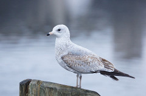

Note: Even though the text inside of the square brackets is not displayed, it’s important to include a description of the image. People who are visually impaired may be browsing your web page, and they could be using software that will read them a description of the image.

### Quotes

```
> Good night, Mrs. Calabash, wherever you are.
```

> Good night, Mrs. Calabash, wherever you are.

### Code

````
```
// This is a Java program from
// https://docs.oracle.com/javase/tutorial/getStarted/application/

class HelloWorldApp {
    public static void main(String[] args) {
        System.out.println("Hello World!"); // Display the string.
    }
}

```
````

```
// This is a Java program from
// https://docs.oracle.com/javase/tutorial/getStarted/application/

class HelloWorldApp {
    public static void main(String[] args) {
        System.out.println("Hello World!"); // Display the string.
    }
}
```

### Inline Code

```
You can use the `c()` function to make vectors.
```

You can use the `c()` function to make vectors.